# Important Python Packages imported.

```python
from pylab import plot,show
from numpy import vstack,array
from numpy.random import rand
from scipy.cluster.vq import kmeans,vq
from sklearn import datasets
import pandas as pd
from sklearn.decomposition import PCA
from sklearn.cluster import KMeans
import pandas as pd
import matplotlib.pyplot as plt
import seaborn as sns
import numpy as np
from scipy.stats import norm
from sklearn.preprocessing import StandardScaler
from scipy import stats
import warnings
import impyute as impy
from sklearn.ensemble import RandomForestRegressor
from sklearn.metrics import roc_auc_score
```

```
C:\Users\abdi K\Anaconda3\lib\site-packages\sklearn\ensemble\weight_boosting.py:29: DeprecationWarning: numpy.core.umath_tests is an internal NumPy module and should not be imported. It will be removed in a future NumPy release.
  from numpy.core.umath_tests import inner1d
```

# Import Data Set Using Pandas.

```python
Cancer = pd.read_csv('C:/Users/abdi K/Documents/PoB-Coursework/risk_factors_cervical_cancer (2).csv')
```

# Check Data Type

```python
Cancer.info()
```

```
<class 'pandas.core.frame.DataFrame'>
RangeIndex: 858 entries, 0 to 857
Data columns (total 36 columns):
Age                                   858 non-null int64
Number of sexual partners             858 non-null object
First sexual intercourse              858 non-null object
Num of pregnancies                    858 non-null object
Smokes                                858 non-null object
Smokes (years)                        858 non-null object
Smokes (packs/year)                   858 non-null object
Hormonal Contraceptives               858 non-null object
Hormonal Contraceptives (years)       858 non-null object
IUD                                   858 non-null object
IUD (years)                           858 non-null object
STDs                                  858 non-null object
STDs (number)                         858 non-null object
STDs:condylomatosis                   858 non-null object
STDs:cervical condylomatosis          858 non-null object
STDs:vaginal condylomatosis           858 non-null object
STDs:vulvo-perineal condylomatosis    858 non-null object
STDs:syphilis                         858 non-null object
STDs:pelvic inflammatory disease      858 non-null object
STDs:genital herpes                   858 non-null object
STDs:molluscum contagiosum            858 non-null object
STDs:AIDS                             858 non-null object
STDs:HIV                              858 non-null object
STDs:Hepatitis B                      858 non-null object
STDs:HPV                              858 non-null object
STDs: Number of diagnosis             858 non-null int64
STDs: Time since first diagnosis      858 non-null object
STDs: Time since last diagnosis       858 non-null object
Dx:Cancer                             858 non-null int64
Dx:CIN                                858 non-null int64
Dx:HPV                                858 non-null int64
Dx                                    858 non-null int64
Hinselmann                            858 non-null int64
Schiller                              858 non-null int64
Citology                              858 non-null int64
Biopsy                                858 non-null int64
dtypes: int64(10), object(26)
memory usage: 241.4+ KB
```

^ There are 5 columns that have to be deleted, 3 target variables and 2 features. 1) STDs: Time since first diagnosis 2) STDs: Time since last diagnosis 3) Hinselmann 4) Schiller 5) Citology

Also object data type has to be converted to numeric or integer for preprocessing.

# Count Of Biopsy Positive/Negative.

```python
Cancer['Biopsy'].value_counts()
```

```
0    803
1     55
Name: Biopsy, dtype: int64
```

# Fill Missing Values with 'NaN'

```python
Cancerna = Cancer.replace('?', np.nan)
```

# Find Column Totals of Missing Values

```python
Cancerna.isnull().sum()
```

```
Age                                     0
Number of sexual partners              26
First sexual intercourse                7
Num of pregnancies                     56
Smokes                                 13
Smokes (years)                         13
Smokes (packs/year)                    13
Hormonal Contraceptives               108
Hormonal Contraceptives (years)       108
IUD                                   117
IUD (years)                           117
STDs                                  105
STDs (number)                         105
STDs:condylomatosis                   105
STDs:cervical condylomatosis          105
STDs:vaginal condylomatosis           105
STDs:vulvo-perineal condylomatosis    105
STDs:syphilis                         105
STDs:pelvic inflammatory disease      105
STDs:genital herpes                   105
STDs:molluscum contagiosum            105
STDs:AIDS                             105
STDs:HIV                              105
STDs:Hepatitis B                      105
STDs:HPV                              105
STDs: Number of diagnosis               0
STDs: Time since first diagnosis      787
STDs: Time since last diagnosis       787
Dx:Cancer                               0
Dx:CIN                                  0
Dx:HPV                                  0
Dx                                      0
Hinselmann                              0
Schiller                                0
Citology                                0
Biopsy                                  0
dtype: int64
```

^ We Can See that 2 features above have to be omitted as they are missing significant portions.

```python
Cancer = Cancerna
```

^ Re-define Cancerna as Cancer.

# Deletion of 5 Attributes.

```python
Cancer.drop(Cancer.columns[[26,27,32,33,34]], axis=1, inplace=True)
```

# Check How Many Columns Are Empty.

```python
Cancer.isnull().sum()
```

```
Age                                     0
Number of sexual partners              26
First sexual intercourse                7
Num of pregnancies                     56
Smokes                                 13
Smokes (years)                         13
Smokes (packs/year)                    13
Hormonal Contraceptives               108
Hormonal Contraceptives (years)       108
IUD                                   117
IUD (years)                           117
STDs                                  105
STDs (number)                         105
STDs:condylomatosis                   105
STDs:cervical condylomatosis          105
STDs:vaginal condylomatosis           105
STDs:vulvo-perineal condylomatosis    105
STDs:syphilis                         105
STDs:pelvic inflammatory disease      105
STDs:genital herpes                   105
STDs:molluscum contagiosum            105
STDs:AIDS                             105
STDs:HIV                              105
STDs:Hepatitis B                      105
STDs:HPV                              105
STDs: Number of diagnosis               0
Dx:Cancer                               0
Dx:CIN                                  0
Dx:HPV                                  0
Dx                                      0
Biopsy                                  0
dtype: int64
```

^ There are 24 columns with missing values and hence they have to be filled in som way.

# Convert Objects into Numeric For Data Preprocessing

```python
Cancer = Cancer.convert_objects(convert_numeric=True)
```

```
C:\Users\abdi K\Anaconda3\lib\site-packages\ipykernel_launcher.py:1: FutureWarning: convert_objects is deprecated.  To re-infer data dtypes for object columns, use DataFrame.infer_objects()
For all other conversions use the data-type specific converters pd.to_datetime, pd.to_timedelta and pd.to_numeric.
  """Entry point for launching an IPython kernel.
```

# Fill Columns with Mean/Median.

```python
Cancer['Number of sexual partners'] = Cancer['Number of sexual partners'].fillna(Cancer['Number of sexual partners'].mean())
Cancer['First sexual intercourse'] = Cancer['First sexual intercourse'].fillna(Cancer['First sexual intercourse'].mean())
Cancer['Num of pregnancies'] = Cancer['Num of pregnancies'].fillna(Cancer['Num of pregnancies'].median())
Cancer['Smokes'] = Cancer['Smokes'].fillna(Cancer['Smokes'].median())
Cancer['Smokes (years)'] = Cancer['Smokes (years)'].fillna(Cancer['Smokes (years)'].mean())
Cancer['Smokes (packs/year)'] = Cancer['Smokes (packs/year)'].fillna(Cancer['Smokes (packs/year)'].mean())
Cancer['Hormonal Contraceptives'] = Cancer['Hormonal Contraceptives'].fillna(Cancer['Hormonal Contraceptives'].median())
Cancer['Hormonal Contraceptives (years)'] = Cancer['Hormonal Contraceptives (years)'].fillna(Cancer['Hormonal Contraceptives (years)'].mean())
Cancer['IUD'] = Cancer['IUD'].fillna(Cancer['IUD'].median())
Cancer['IUD (years)'] = Cancer['IUD (years)'].fillna(Cancer['IUD (years)'].mean())
Cancer['STDs'] = Cancer['STDs'].fillna(Cancer['STDs'].median())
Cancer['STDs (number)'] = Cancer['STDs (number)'].fillna(Cancer['STDs (number)'].median())
Cancer['STDs:condylomatosis'] = Cancer['STDs:condylomatosis'].fillna(Cancer['STDs:condylomatosis'].median())
Cancer['STDs:cervical condylomatosis'] = Cancer['STDs:cervical condylomatosis'].fillna(Cancer['STDs:cervical condylomatosis'].median())
Cancer['STDs:vaginal condylomatosis'] = Cancer['STDs:vaginal condylomatosis'].fillna(Cancer['STDs:vaginal condylomatosis'].median())
Cancer['STDs:vulvo-perineal condylomatosis'] = Cancer['STDs:vulvo-perineal condylomatosis'].fillna(Cancer['STDs:vulvo-perineal condylomatosis'].median())
Cancer['STDs:syphilis'] = Cancer['STDs:syphilis'].fillna(Cancer['STDs:syphilis'].median())
Cancer['STDs:pelvic inflammatory disease'] = Cancer['STDs:pelvic inflammatory disease'].fillna(Cancer['STDs:pelvic inflammatory disease'].median())
Cancer['STDs:genital herpes'] = Cancer['STDs:genital herpes'].fillna(Cancer['STDs:genital herpes'].median())
Cancer['STDs:molluscum contagiosum'] = Cancer['STDs:molluscum contagiosum'].fillna(Cancer['STDs:molluscum contagiosum'].median())
Cancer['STDs:AIDS'] = Cancer['STDs:AIDS'].fillna(Cancer['STDs:AIDS'].median())
Cancer['STDs:HIV'] = Cancer['STDs:HIV'].fillna(Cancer['STDs:HIV'].median())
Cancer['STDs:Hepatitis B'] = Cancer['STDs:Hepatitis B'].fillna(Cancer['STDs:Hepatitis B'].median())
Cancer['STDs:HPV'] = Cancer['STDs:HPV'].fillna(Cancer['STDs:HPV'].median())
```

^ Fill continuous Variables with column mean and discrete/boolean variables with column median. There are 24 columns remaining in my final data set that have missing values. there are 6 columns that are continuous, such as; measurement in years. The remaining are all filled with the column-median.

# Check All columns have been filled/Summary statistics.

```python
Cancer.isnull().sum()
```

```
Age                                   0
Number of sexual partners             0
First sexual intercourse              0
Num of pregnancies                    0
Smokes                                0
Smokes (years)                        0
Smokes (packs/year)                   0
Hormonal Contraceptives               0
Hormonal Contraceptives (years)       0
IUD                                   0
IUD (years)                           0
STDs                                  0
STDs (number)                         0
STDs:condylomatosis                   0
STDs:cervical condylomatosis          0
STDs:vaginal condylomatosis           0
STDs:vulvo-perineal condylomatosis    0
STDs:syphilis                         0
STDs:pelvic inflammatory disease      0
STDs:genital herpes                   0
STDs:molluscum contagiosum            0
STDs:AIDS                             0
STDs:HIV                              0
STDs:Hepatitis B                      0
STDs:HPV                              0
STDs: Number of diagnosis             0
Dx:Cancer                             0
Dx:CIN                                0
Dx:HPV                                0
Dx                                    0
Biopsy                                0
dtype: int64
```

```python
Cancer.describe()
```

|  | Age | Number of sexual partners | First sexual intercourse | Num of pregnancies | Smokes | Smokes (years) | Smokes (packs/year) | Hormonal Contraceptives | Hormonal Contraceptives (years) | IUD | ... | STDs:AIDS | STDs:HIV | STDs:Hepatitis B | STDs:HPV | STDs: Number of diagnosis | Dx:Cancer | Dx:CIN | Dx:HPV | Dx | Biopsy |
| --- | --- | --- | --- | --- | --- | --- | --- | --- | --- | --- | --- | --- | --- | --- | --- | --- | --- | --- | --- | --- | --- |
| count | 858.000000 | 858.000000 | 858.000000 | 858.000000 | 858.000000 | 858.000000 | 858.000000 | 858.000000 | 858.000000 | 858.000000 | ... | 858.0 | 858.000000 | 858.000000 | 858.000000 | 858.000000 | 858.000000 | 858.000000 | 858.000000 | 858.000000 | 858.000000 |
| mean | 26.820513 | 2.527644 | 16.995300 | 2.257576 | 0.143357 | 1.219721 | 0.453144 | 0.686480 | 2.256419 | 0.096737 | ... | 0.0 | 0.020979 | 0.001166 | 0.002331 | 0.087413 | 0.020979 | 0.010490 | 0.020979 | 0.027972 | 0.064103 |
| std | 8.497948 | 1.642267 | 2.791883 | 1.400981 | 0.350641 | 4.057885 | 2.209657 | 0.464194 | 3.519082 | 0.295771 | ... | 0.0 | 0.143398 | 0.034139 | 0.048252 | 0.302545 | 0.143398 | 0.101939 | 0.143398 | 0.164989 | 0.245078 |
| min | 13.000000 | 1.000000 | 10.000000 | 0.000000 | 0.000000 | 0.000000 | 0.000000 | 0.000000 | 0.000000 | 0.000000 | ... | 0.0 | 0.000000 | 0.000000 | 0.000000 | 0.000000 | 0.000000 | 0.000000 | 0.000000 | 0.000000 | 0.000000 |
| 25% | 20.000000 | 2.000000 | 15.000000 | 1.000000 | 0.000000 | 0.000000 | 0.000000 | 0.000000 | 0.000000 | 0.000000 | ... | 0.0 | 0.000000 | 0.000000 | 0.000000 | 0.000000 | 0.000000 | 0.000000 | 0.000000 | 0.000000 | 0.000000 |
| 50% | 25.000000 | 2.000000 | 17.000000 | 2.000000 | 0.000000 | 0.000000 | 0.000000 | 1.000000 | 1.000000 | 0.000000 | ... | 0.0 | 0.000000 | 0.000000 | 0.000000 | 0.000000 | 0.000000 | 0.000000 | 0.000000 | 0.000000 | 0.000000 |
| 75% | 32.000000 | 3.000000 | 18.000000 | 3.000000 | 0.000000 | 0.000000 | 0.000000 | 1.000000 | 2.256419 | 0.000000 | ... | 0.0 | 0.000000 | 0.000000 | 0.000000 | 0.000000 | 0.000000 | 0.000000 | 0.000000 | 0.000000 | 0.000000 |
| max | 84.000000 | 28.000000 | 32.000000 | 11.000000 | 1.000000 | 37.000000 | 37.000000 | 1.000000 | 30.000000 | 1.000000 | ... | 0.0 | 1.000000 | 1.000000 | 1.000000 | 3.000000 | 1.000000 | 1.000000 | 1.000000 | 1.000000 | 1.000000 |

8 rows × 31 columns

# Heatmap for Attribute Correlation.

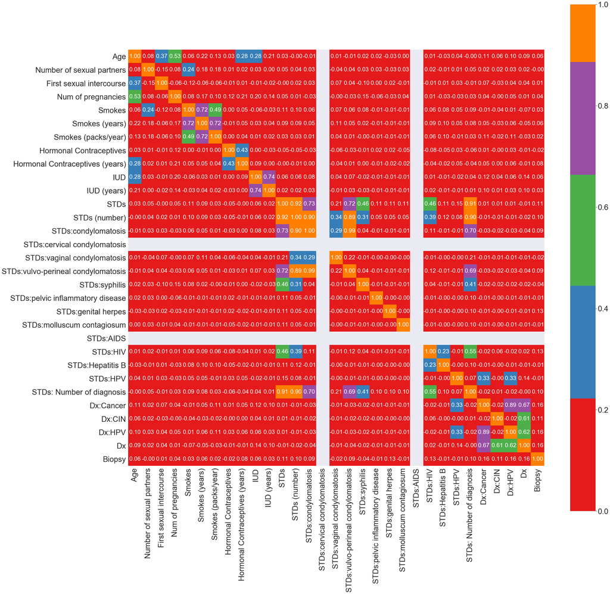

```python
correlationMap = Cancer.corr()

plt.figure(figsize=(40,40))

sns.set(font_scale=3)
hm = sns.heatmap(correlationMap,cmap = 'Set1', cbar=True, annot=True,vmin=0,vmax =1,center=True, square=True, fmt='.2f', annot_kws={'size': 25},
             yticklabels = Cancer.columns, xticklabels = Cancer.columns)
plt.show()
```

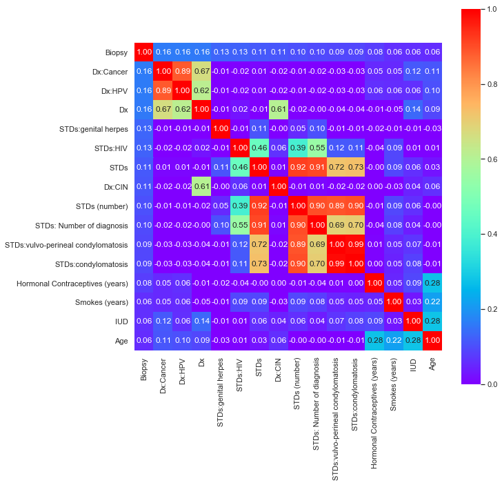

```python
correlationMap = Cancer.corr()
k = 16
correlations = correlationMap.nlargest(k, 'Biopsy')['Biopsy'].index



M = Cancer[correlations].corr()

plt.figure(figsize=(10,10))

sns.set(font_scale=1)
H = sns.heatmap(M, cbar=True, cmap='rainbow' ,annot=True,vmin=0,vmax =1, square=True, fmt='.2f', annot_kws={'size': 12},
                 yticklabels = correlations.values, xticklabels = correlations.values)
plt.show()
```

# Comparison Of Biopsy Result For Attributes

```
Biopsy                                      0          1
Age                                 26.696139  28.636364
Number of sexual partners            2.528258   2.518684
First sexual intercourse            16.989996  17.072727
Num of pregnancies                   2.242839   2.472727
Smokes                               0.140722   0.181818
Smokes (years)                       1.154464   2.172485
Smokes (packs/year)                  0.438893   0.661206
Hormonal Contraceptives              0.688667   0.654545
Hormonal Contraceptives (years)      2.183708   3.318000
IUD                                  0.092154   0.163636
IUD (years)                          0.499574   0.737171
STDs                                 0.083437   0.218182
STDs (number)                        0.140722   0.363636
STDs:condylomatosis                  0.046077   0.127273
STDs:cervical condylomatosis         0.000000   0.000000
STDs:vaginal condylomatosis          0.004981   0.000000
STDs:vulvo-perineal condylomatosis   0.044832   0.127273
STDs:syphilis                        0.022416   0.000000
STDs:pelvic inflammatory disease     0.001245   0.000000
STDs:genital herpes                  0.000000   0.018182
STDs:molluscum contagiosum           0.001245   0.000000
STDs:AIDS                            0.000000   0.000000
STDs:HIV                             0.016189   0.090909
STDs:Hepatitis B                     0.001245   0.000000
STDs:HPV                             0.002491   0.000000
STDs: Number of diagnosis            0.079701   0.200000
Dx:Cancer                            0.014944   0.109091
Dx:CIN                               0.007472   0.054545
Dx:HPV                               0.014944   0.109091
Dx                                   0.021171   0.127273
```

```
C:\Users\abdi K\Anaconda3\lib\site-packages\scipy\stats\stats.py:1713: FutureWarning: Using a non-tuple sequence for multidimensional indexing is deprecated; use `arr[tuple(seq)]` instead of `arr[seq]`. In the future this will be interpreted as an array index, `arr[np.array(seq)]`, which will result…
  return np.add.reduce(sorted[indexer] * weights, axis=axis) / sumval
```

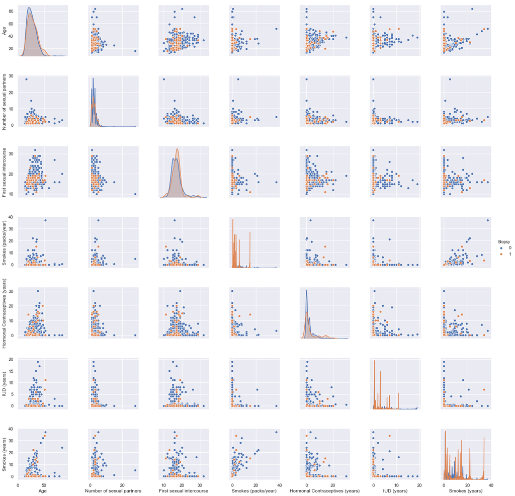

```python
new_col= Cancer.groupby('Biopsy').mean()
print(new_col.head().T)

cols = ['Age', 'Number of sexual partners',
        'First sexual intercourse', 'Smokes (packs/year)',
         'Hormonal Contraceptives (years)','IUD (years)', 'Smokes (years)']

sns.pairplot(Cancer,
             x_vars = cols,
             y_vars = cols,
             hue = 'Biopsy',)
```

^ Above we have a 31 by 3 matrix. First Row of 'Biopsy' is divided into its two categories, that is 0 and 1, 0 = negative and 1 = positive for onset of cervical cancer. The following rows are all the remaining 30 features. The average is calculated for each feature, this average is for all values corresponding to 0 and 1 for biopsy-method. We can see that there are 8 features completely free from a positive reading of cervcal cancer.

1) STDs:cervical condylomatosis 2) STDs:vaginal condylomatosis 3) STDs:syphilis 4) STDs:pelvic inflammatory disease 5) STDs:molluscum contagiosum 6) STDs:HPV 7) STDs:AIDS  
8) STDs:Hepatitis B

Human papilloma virus (HPV) is given to be the prime causer of cervical cancer [5]. In our investiagtion above, it seems not to be detected at all by biopsy screening method, suggesting it has no effect on cervical cancer or that screening method is very inaccurate.

1) number of sexual partners 2) Hormonal contraceptives 3) STDs:pelvic inflammatory disease

# ^ Multiple Pairwise Bivariate Distributions

Observing graph of 'First sexual intercourse' by 'Age', it is visible that < 20 years for 'first sexual intercourse' and < 40 for 'Age' has an increased occurence of positive reading in Biopsy. Also 'First sexual intercourse' by 'Number of sexual partners' has positive readings concentrated around < 20 years for 'First sexual intercourse' and < 10 for 'Number of sexual partners'.

# Random Forest Regressor

Random forest is an ensemble algorithm that takes observations and variables and then creates decision trees. It is useful as it builds multiple decision trees then takes an average for an enhanced accuracey as compared to decision trees.

# Creation of New columns From Existing Attributes for RF.

YRSS:Years passed since patient had first sexual intercourse NSPP:Number of sexual partners since first time as a percentage. HPA: Hormonal Contraceptives/age TPS:Total packets of cigarettes smoked NPA:Number of pregnancies/age NSA:Number of sexual partners/age NYHC:number of years patient did not take Hormonal Contraceptives APP:number of pregnancy/number of sexual partner NHCP:number of years patient took Hormonal Contraceptives after first sexual intercourse as a percentage

```python
Cancer['YRSS'] = Cancer['Age'] - Cancer['First sexual intercourse']
Cancer['NSPP'] = Cancer['Number of sexual partners'] / Cancer['YRSS']
Cancer['HPA'] = Cancer['Hormonal Contraceptives (years)'] / Cancer['Age']
Cancer['TPS'] = Cancer['Smokes (packs/year)'] * Cancer['Smokes (years)']
Cancer['NPA'] = Cancer['Num of pregnancies'] / Cancer['Age']
Cancer['NSA'] = Cancer['Number of sexual partners'] / Cancer['Age']
Cancer['NYHC'] = Cancer['Age'] - Cancer['Hormonal Contraceptives (years)']
Cancer['APP'] = Cancer['Num of pregnancies'] / Cancer['Number of sexual partners']
Cancer['NHCP'] = Cancer['Hormonal Contraceptives (years)'] / Cancer['YRSS']
```

^ Above, I have decided to create new columns that might better explain a positive reading of cervical cancer.

```python
X = Cancer.drop('Biopsy', axis =1)
Y = Cancer["Biopsy"]
```

^ We have defined X and Y.

Due to the division of columns above, there will be instances of division by zero; giving 'infinity', hence the need to replace 'infinity' with 0.

```python
x = X.replace([np.inf], 0)
```

We check to see that all columns are full for RF algorithm to run.

```python
x.isnull().sum()
```

```
Age                                    0
Number of sexual partners              0
First sexual intercourse               0
Num of pregnancies                     0
Smokes                                 0
Smokes (years)                         0
Smokes (packs/year)                    0
Hormonal Contraceptives                0
Hormonal Contraceptives (years)        0
IUD                                    0
IUD (years)                            0
STDs                                   0
STDs (number)                          0
STDs:condylomatosis                    0
STDs:cervical condylomatosis           0
STDs:vaginal condylomatosis            0
STDs:vulvo-perineal condylomatosis     0
STDs:syphilis                          0
STDs:pelvic inflammatory disease       0
STDs:genital herpes                    0
STDs:molluscum contagiosum             0
STDs:AIDS                              0
STDs:HIV                               0
STDs:Hepatitis B                       0
STDs:HPV                               0
STDs: Number of diagnosis              0
Dx:Cancer                              0
Dx:CIN                                 0
Dx:HPV                                 0
Dx                                     0
YRSS                                   0
NSPP                                   0
HPA                                    0
TPS                                    0
NPA                                    0
NSA                                    0
NYHC                                   0
APP                                    0
NHCP                                  16
dtype: int64
```

^ Column 'NHCP' is missing 16 values, we fill with its mean.

```python
x['NHCP'] = x['NHCP'].fillna(x['NHCP'].mean())
```

```python
x.isnull().sum()
```

```
Age                                   0
Number of sexual partners             0
First sexual intercourse              0
Num of pregnancies                    0
Smokes                                0
Smokes (years)                        0
Smokes (packs/year)                   0
Hormonal Contraceptives               0
Hormonal Contraceptives (years)       0
IUD                                   0
IUD (years)                           0
STDs                                  0
STDs (number)                         0
STDs:condylomatosis                   0
STDs:cervical condylomatosis          0
STDs:vaginal condylomatosis           0
STDs:vulvo-perineal condylomatosis    0
STDs:syphilis                         0
STDs:pelvic inflammatory disease      0
STDs:genital herpes                   0
STDs:molluscum contagiosum            0
STDs:AIDS                             0
STDs:HIV                              0
STDs:Hepatitis B                      0
STDs:HPV                              0
STDs: Number of diagnosis             0
Dx:Cancer                             0
Dx:CIN                                0
Dx:HPV                                0
Dx                                    0
YRSS                                  0
NSPP                                  0
HPA                                   0
TPS                                   0
NPA                                   0
NSA                                   0
NYHC                                  0
APP                                   0
NHCP                                  0
dtype: int64
```

# Now we are ready to run RF algorithm.

```python
%timeit
```

```python
model = RandomForestRegressor(max_features = 7, n_estimators = 100, n_jobs = -1, oob_score = True, random_state = 42)
```

```python
model.fit(x,Y)
```

```
RandomForestRegressor(bootstrap=True, criterion='mse', max_depth=None,
           max_features=7, max_leaf_nodes=None, min_impurity_decrease=0.0,
           min_impurity_split=None, min_samples_leaf=1,
           min_samples_split=2, min_weight_fraction_leaf=0.0,
           n_estimators=100, n_jobs=-1, oob_score=True, random_state=42,
           verbose=0, warm_start=False)
```

max_features: This is the maximum number of variables RF is allowed to test in each node. An increase in variables to be tested at each node generally improves performance, the downside is diversity of each node is reduced which is the unique selling point of RF. For our classification problem, I will use sqaure root of count of variables, which in our case is 6.24 but rounded to 7.

n_estimators: This is the number of trees that are built before average is taken, ideal to have high number of trees, downside is code runs slower.

n_jobs: This code tells engine how many processors to use, "1" for one processor and "-1" for unrestricted.

random_state: Thise code allows solution to be easily replicated.

oob_score: This is a RF cross-validation method.

We have out of bag score, the trailing underscore after "score" means R^2 is available after model has been trained. We have a R^2 = 0.00317, this is very low.

```python
model.oob_score_
```

```
0.003173224463999813
```

We will calculate a C-stat. The C-statistic also called concordance statistic gives a measure of goodness of fit for binary outcomes in a logistic regression model. It will give us the probability a randomly selected patient who has experienced cervical cancer risks has a higher risk score than a patient who has not experienced the risks. It is equal to the area under the Receiver Operating Characteristic (ROC) curve.

```python
Y_oob = model.oob_prediction_
```

```python
print("C-Stat: ", roc_auc_score(Y, Y_oob))
```

```
C-Stat:  0.6645194158270123
```

^ We have a C-stat of 0.6645, This will be our benchmark and I will try to improve this C-stat value, also C-stat ranges from 0.5 to 1, usually values from and above 0.70 are considered good model fit.

Y_oob = Y out of bag, this gives the prediction for every single observation. We can see that a lot of observations have 0 predictions and the remaining have low predictions.

```python
Y_oob
```

[output not shown]

[output cut: 117 more lines]

[output not shown]

# Improving Model

I will introduce dummy variables for all categorical variables in my data set. This is done to capture directionality of the categorical variables, also dummy variables allow us to use one regression equation to represent many groups. K-1, where k is the number of levels for a variable determines how many dummy variables to use.

```python
categorical_variables = ["Smokes", "Hormonal Contraceptives", "IUD", "STDs", "STDs:condylomatosis",
"STDs:cervical condylomatosis", "STDs:vaginal condylomatosis", "STDs:vulvo-perineal condylomatosis", "STDs:syphilis",
"STDs:pelvic inflammatory disease", "STDs:genital herpes", "STDs:molluscum contagiosum", "STDs:AIDS", "STDs:HIV",
 "STDs:Hepatitis B", "STDs:HPV", "Dx:Cancer", "Dx:CIN", "Dx:HPV", "Dx"]
for variable in categorical_variables :
    dummies= pd.get_dummies(x[variable], prefix=variable)
    x=pd.concat([x, dummies], axis=1)
    x.drop([variable], axis=1, inplace=True)
```

```python
model = RandomForestRegressor(max_features = 8, n_estimators = 100, n_jobs = -1, oob_score = True, random_state = 42)
model.fit(x,Y)
```

```
RandomForestRegressor(bootstrap=True, criterion='mse', max_depth=None,
           max_features=8, max_leaf_nodes=None, min_impurity_decrease=0.0,
           min_impurity_split=None, min_samples_leaf=1,
           min_samples_split=2, min_weight_fraction_leaf=0.0,
           n_estimators=100, n_jobs=-1, oob_score=True, random_state=42,
           verbose=0, warm_start=False)
```

```python
print("C-stat : ", roc_auc_score(Y, model.oob_prediction_))
```

```
C-stat :  0.6879542624249972
```

^ after introducing dummy variables for all the categorical variables, we get a slight improvement of the model. This is a 3.4% improvement which is not enough to reach our mark of 0.7.

# Plot And Sort Features Importance

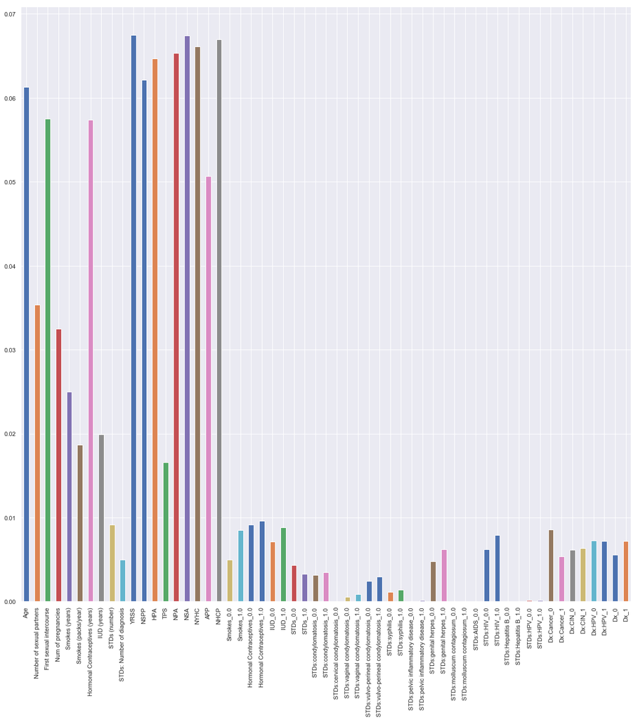

```python
feature_importances= pd.Series(model.feature_importances_, index=x.columns)
feature_importances.plot(kind="bar", figsize=(20,20));
```

^ The Most important features are by a large margin, the columns created from existing attributes, namely; (1) YRSS = Years passed since patient had first sexual intercourse (2) NSA = Number of sexual partners/age. (3) NHCP = number of years patient took Hormonal Contraceptives after first sexual intercourse as a percentage  
(4) NYHC = number of years patient did not take Hormonal Contraceptives

These Features are somewhat correlated with a positive reading on a Biopsy screening method, it is a very weak correlation.

# Finding Optimal Number Of Trees For RF

```
C:\Users\abdi K\Anaconda3\lib\site-packages\sklearn\ensemble\forest.py:724: UserWarning: Some inputs do not have OOB scores. This probably means too few trees were used to compute any reliable oob estimates.
  warn("Some inputs do not have OOB scores. "
```

```
10 trees
C-stat :  0.5939884523944301

20 trees
C-stat :  0.6143665798709386

30 trees
C-stat :  0.6391373259368278

40 trees
C-stat :  0.6358428619947922

50 trees
C-stat :  0.6532774821691385

60 trees
C-stat :  0.6582361598550889

70 trees
C-stat :  0.6582361598550889

80 trees
C-stat :  0.6614060907958791

90 trees
C-stat :  0.6646326276463264

100 trees
C-stat :  0.6690478885995699

110 trees
C-stat :  0.6697045171515906

120 trees
C-stat :  0.6774368844107325

130 trees
C-stat :  0.6716517604437904

140 trees
C-stat :  0.6798482961621193

150 trees
C-stat :  0.6792256311558925

200 trees
C-stat :  0.669976225517944
```

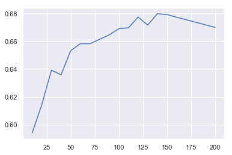

```python
results=[]
n_estimator_values=[10,20,30,40,50,60,70,80,90,100,110,120,130,140,150,200]
for trees in n_estimator_values:
    model=RandomForestRegressor(trees, oob_score=True, n_jobs=-1,random_state=42)
    model.fit(x, Y)
    print(trees, "trees")
    roc_score=roc_auc_score(Y, model.oob_prediction_)
    print("C-stat : ", roc_score)
    results.append(roc_score)
    print(" ")
pd.Series(results, n_estimator_values).plot();
```

^ 140 trees gives us the highest c-stat, i.e. 0.6798.

# Finding Optimal Max_Features For RF

```
auto option
C-stat :  0.6798482961621193

sqrt option
C-stat :  0.7038492018566738

log2 option
C-stat :  0.7070870598890525

None option
C-stat :  0.6798482961621193

0.2 option
C-stat :  0.667700667949734

0.9 option
C-stat :  0.6908185214536399
```

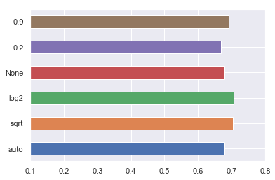

```python
results=[]
max_features_values=["auto", "sqrt", "log2", None, 0.2, 0.9]
for max_features in max_features_values:
    model=RandomForestRegressor(n_estimators=140, oob_score=True, n_jobs=-1,random_state=42,
                                max_features=max_features)
    model.fit(x, Y)
    print(max_features, "option")
    roc_score=roc_auc_score(Y, model.oob_prediction_)
    print("C-stat : ", roc_score)
    results.append(roc_score)
    print(" ")
pd.Series(results, max_features_values).plot(kind="barh", xlim=(0.10, 0.8));
```

^ max_features, as a recap is; the maximum number of variables RF is allowed to test in each node. The optimal for our model is log2.

# Finding Optimal Min_Samples_Leaf For RF

```
1 min sample
C-stat :  0.7070870598890525

2 min sample
C-stat :  0.7030680403034076

3 min sample
C-stat :  0.6757613494848862

4 min sample
C-stat :  0.6862674063172194

5 min sample
C-stat :  0.6953017094984716

6 min sample
C-stat :  0.6974753764292991

7 min sample
C-stat :  0.7001471753651081

8 min sample
C-stat :  0.7057398392392166

9 min sample
C-stat :  0.7018000679270915

10 min sample
C-stat :  0.685361711762708

11 min sample
C-stat :  0.683663534472999

12 min sample
C-stat :  0.6632401222687648

13 min sample
C-stat :  0.6666817615759084

14 min sample
```

[output cut: 13 more lines]

```

19 min sample
C-stat :  0.6366806294577154

20 min sample
C-stat :  0.634484320163025

100 min sample
C-stat :  0.502071776293445

140 min sample
C-stat :  0.4864032605003963

200 min sample
C-stat :  0.4899807539907166
```

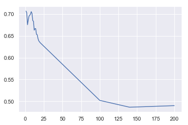

```python
results=[]
min_sample_leaf_values=[1,2,3,4,5,6,7,8,9,10,11,12,13,14,15,16,17,18,19,20,100,140,200]
for min_sample in min_sample_leaf_values:
    model=RandomForestRegressor(n_estimators=140, oob_score=True, n_jobs=-1,random_state=42,
                                max_features="log2", min_samples_leaf=min_sample)
    model.fit(x, Y)
    print(min_sample, "min sample")
    roc_score=roc_auc_score(Y, model.oob_prediction_)
    print("C-stat : ", roc_score)
    results.append(roc_score)
    print(" ")
pd.Series(results, min_sample_leaf_values).plot();
```

min_samples_leaf: This is the minimum number of samples required to be at each node. The optimal for our model is; 1.

# Final Optimised Model

```python
model=RandomForestRegressor(n_estimators=140, oob_score=True, n_jobs=-1,random_state=42,
                            max_features="log2", min_samples_leaf=1)
model.fit(x, Y)
roc_score=roc_auc_score(Y, model.oob_prediction_)
print("C-stat : ", roc_score)
```

```
C-stat :  0.7070870598890525
```

^ We have achieved the desired 0.70 mark, this means our model has just passed the threshold of a good model fit.